# metalworkingsolutions-pandas

1. Do an analysis of customers. The customer can be identified using the jmp_customer_organization_id from the jobs table or the omp_customer_organization_id from the sales_orders table. Here are some example questions to get started:
   1. Which customers have the highest volume of jobs? Which generate the most revenue (as indicated by the omp_order_subtotal_base in the sales_order table)?
   2. How has the volume of work changed for each customer over time? Are there any seasonal patterns? How have the number of estimated hours per customer changed over time? Estimated hours are in the jmo_estimated_production_hours columns of the job_operations_2023/job_operations_2024 tables.
   3. How has the customer base changed over time? What percentage of jobs are for new customers compared to repeat customers?
   4. Perform a breakdown of customers by operation (as indicated by the jmo_process short_description in the job_operations_2023 or job_operations_2024 table).** */

Import libraries

```r
library(DBI) # not postgres specific
library(RPostgres) # gives us the postgres driver
library(tidyverse)
```

Create connection

```r
connection <- dbConnect(
  Postgres(), # Use the postgres driver # nolint
  dbname = "metalworkingsolutions", # Name of the database we want to connect to
  host = "localhost",
  port = 5432,
  user = "postgres",
  password = Sys.getenv("DB_PASSWORD")
  # password = rstudioapi::askForPassword("Database password")
  )
```

list tables in database `dbListTables(connection)`

List all fields in a table `dbListFields(connection, 'jobs')`

**b. How has the volume of work changed for each customer over time? Are there any seasonal patterns? How have the number of estimated hours per customer changed over time? Estimated hours are in the jmo_estimated_production_hours columns of the job_operations_2023/job_operations_2024 tables.**

```r
query <- "SELECT * FROM job_operations_2023"
result_set <- dbSendQuery(connection, query)
```

```r
job_operations_2023 <- dbFetch(result_set)
dbListFields(connection, "job_operations_2023")
```

```
 [1] "jmo_job_id"                        "jmo_job_assembly_id"
 [3] "jmo_job_operation_id"              "jmo_operation_type"
 [5] "jmo_added_operation"               "jmo_prototype_operation"
 [7] "jmo_plant_department_id"           "jmo_plant_id"
 [9] "jmo_work_center_id"                "jmo_process_id"
[11] "jmo_process_short_description"     "jmo_process_long_description_text"
[13] "jmo_quantity_per_assembly"         "jmo_queue_time"
[15] "jmo_setup_hours"                   "jmo_production_standard"
[17] "jmo_standard_factor"               "jmo_setup_rate"
[19] "jmo_production_rate"               "jmo_overhead_rate"
[21] "jmo_operation_quantity"            "jmo_quantity_complete"
[23] "jmo_setup_percent_complete"        "jmo_actual_setup_hours"
[25] "jmo_actual_production_hours"       "jmo_quantity_to_inspect"
[27] "jmo_scrap_quantity_received"       "jmo_quantity_to_return"
[29] "jmo_move_time"                     "jmo_setup_complete"
```

[output cut: 34 more lines]

[output not shown]

[output cut: 138 more lines]

[output not shown]

```r
dbClearResult(result_set)
```

```r
query <- "SELECT
    jmo_job_id,
    date_trunc('week', jmo_created_date) AS week,
    SUM(jmo_estimated_production_hours) AS total_estimated_hours
    FROM job_operations_2023
    GROUP BY jmo_job_id, date_trunc('week', jmo_created_date)
    ORDER BY week;"
result_set <- dbSendQuery(connection, query)
job_ops_23_slimmed <- dbFetch(result_set)
dbClearResult(result_set)
job_ops_23_slimmed
```

| jmo_job_id | week | total_estimated_hours |
| --- | --- | --- |
| 27569-0004-001 | 2023-01-02 | 0.31 |
| 27593-0001-001 | 2023-01-02 | 6.20 |
| 27598-0005-001 | 2023-01-02 | 181.00 |
| 27592-0001-001 | 2023-01-02 | 8.60 |
| 27548-0001-001 | 2023-01-02 | 5.96 |
| 27566-0002-001 | 2023-01-02 | 5.52 |
| 27567-0004-001 | 2023-01-02 | 11.96 |
| 27560-0002-001 | 2023-01-02 | 4.39 |
| 27583-0001-001 | 2023-01-02 | 2.96 |
| 27589-0001-001 | 2023-01-02 | 11.82 |

[output cut: 8755 more lines]

Create query

```r
query <- "SELECT
    date_trunc('week', jmo_created_date) AS week,
    SUM(jmo_estimated_production_hours) AS jmo_estimated_production_hours
    FROM job_operations_2023
    GROUP BY date_trunc('week', jmo_created_date)
    ORDER BY week;"
result_set <- dbSendQuery(connection, query)
```

```r
jobs_volume_hours <- dbFetch(result_set)
dbClearResult(result_set)
```

Plot jobs_volume_hours

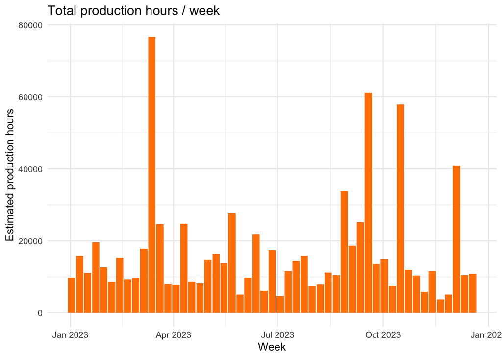

```r
jobs_volume_hours |>
  ggplot(aes(x = week, y = jmo_estimated_production_hours)) +
  geom_col(fill = "#ff8200") +
  labs(title = "Total production hours / week",
       x = "Week",
       y = "Estimated production hours") +
  theme_minimal()
```

```r
query <- "SELECT
    EXTRACT(MONTH FROM jmo_created_date) AS month,
    SUM(jmo_estimated_production_hours) AS jmo_estimated_production_hours
    FROM job_operations_2023
    GROUP BY jmo_created_date, date_trunc('month', jmo_created_date)
    ORDER BY month;"
result_set <- dbSendQuery(connection, query)
```

```r
jobs_volume_hours_month <- dbFetch(result_set)
dbClearResult(result_set)
```

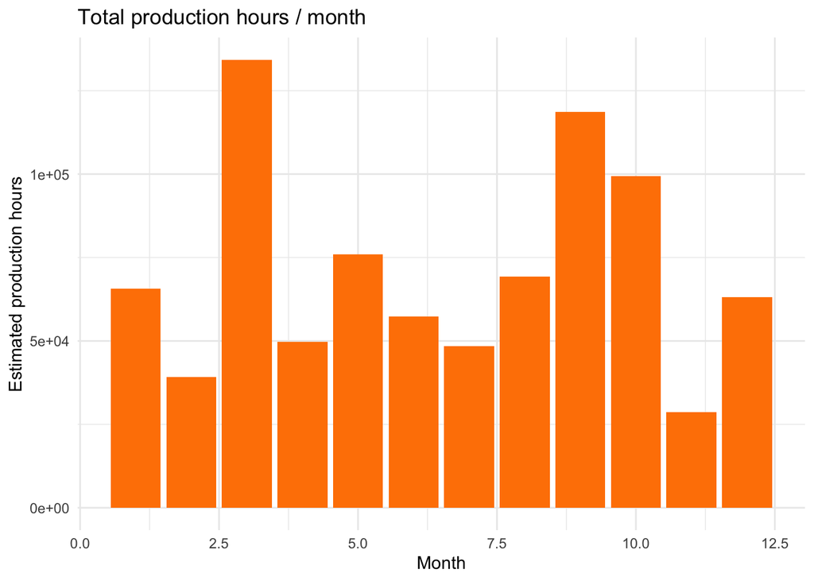

```r
jobs_volume_hours_month |>
  ggplot(aes(x = month, y = jmo_estimated_production_hours)) +
  geom_col(fill = "#ff8200") +
  labs(title = "Total production hours / month",
       x = "Month",
       y = "Estimated production hours") +
  theme_minimal()
```